# Case Study: How Does a Bike-Share Navigate Speedy Success?

Victor Olmos

2023-11-01

## Case Study: How Does a Bike-Share Navigate Speedy Success?

(Case study from Google Data Analyst course in Coursera: https://www.coursera.org/learn/google-data-analytics-capstone/)

### Business Task Summary:

Cyclistic (fictional company name) offers bike-sharing in the city of Chicago, including some bikes with assistive options (8% riders use them). Cyclistic offers different pricing plans, single-day and full-day passes for more casual customers, and annual memberships for regular users, or Cyclistic members. It has been observed that annual members are much more profitable than casual customers, so it’s interesting for the company to maximize this kind of customer.

**Thesis:** Casual riders can be converted into Cyclistic members.

**Problem:** Which are the differences and similarities between the 2 types of customers? How can more casual customers become members?

### Data information:

Data has been made available for the bike-share company (Motivate International Inc.) under a license agreement (see link below) to maintain their customers’ privacy.

Data source: https://divvy-tripdata.s3.amazonaws.com/index.html.

Licence agreement: https://divvybikes.com/data-license-agreement.

Data is organized in 13 attribute keys in columns which provide information from each bike trip:

- *ride_id*
- *rideable_type*
- *started_at*
- *ended_at*
- *start_station_name*
- *start_station_id*
- *end_station_name*
- *end_station_id*
- *start_lat*
- *start_lng*
- *end_lat*
- *end_lng*
- *member_casual*

A portion of the dataset is available in Kaggle with a Usability score of 9.4. For this reason, I think that is a reliable dataset. Datasets only contain non-identifiable information, so a previous step with that purpose is not necessary.

No information about the column names has been provided, but names look quite explanatory. Some information in the *start_station_name*, *start_station_id*, *end_station_name* and *end_station_id* is missing. Also, some of the *station_id* are numbers and others are combinations of characters and numbers.

### Data exploration and cleaning:

Install libraries:

```r
if (!require("tidyverse")) { install.packages("tidyverse"); library(tidyverse);
library(readr) }
```

Set work space and load data:

```r
#set workspace
setwd(working_directory)

#initialize dataset
tripdata_2022 <- data.frame(matrix(nrow = 0, ncol = 13))
column_names <- c("ride_id", "rideable_type", "started_at", "ended_at", "start_station_name",
                  "start_station_id", "end_station_name", "end_station_id", "start_lat",
                  "start_lng", "end_lat", "end_lng", "member_casual")
colnames(tripdata_2022) = column_names

#load csv 1 to 8
for (n in 1:8){number <- as.character(n)
document_name <- paste0("20220",number,"-divvy-tripdata.csv")
new_dataset <- read_csv(document_name)
tripdata_2022 <- rbind(tripdata_2022, new_dataset) }

#load csv 9 separately because it has a different name
new_dataset <- read_csv("202209-divvy-publictripdata.csv")
tripdata_2022 <- rbind(tripdata_2022, new_dataset)

#load csv 10 to 12
for (n in 10:12){number <- as.character(n)
document_name <- paste0("2022",number,"-divvy-tripdata.csv")
new_dataset <- read_csv(document_name)
tripdata_2022 <- rbind(tripdata_2022, new_dataset) }
```

Data exploration:

*Stringr* and *skimr* libraries have been loaded. Data summary:

Data summary

| Name | tripdata_2022 |
| --- | --- |
| Number of rows | 5667717 |
| Number of columns | 13 |
| _______________________ |  |
| Column type frequency: |  |
| character | 7 |
| numeric | 4 |
| POSIXct | 2 |
| ________________________ |  |
| Group variables | None |

**Variable type: character**

| skim_variable | n_missing | complete_rate | min | max | empty | n_unique | whitespace |
| --- | --- | --- | --- | --- | --- | --- | --- |
| ride_id | 0 | 1.00 | 16 | 16 | 0 | 5667717 | 0 |
| rideable_type | 0 | 1.00 | 11 | 13 | 0 | 3 | 0 |
| start_station_name | 833064 | 0.85 | 7 | 64 | 0 | 1674 | 0 |
| start_station_id | 833064 | 0.85 | 3 | 44 | 0 | 1313 | 0 |
| end_station_name | 892742 | 0.84 | 9 | 64 | 0 | 1692 | 0 |
| end_station_id | 892742 | 0.84 | 3 | 44 | 0 | 1317 | 0 |
| member_casual | 0 | 1.00 | 6 | 6 | 0 | 2 | 0 |

**Variable type: numeric**

| skim_variable | n_missing | complete_rate | mean | sd | p0 | p25 | p50 | p75 | p100 |
| --- | --- | --- | --- | --- | --- | --- | --- | --- | --- |
| start_lat | 0 | 1 | 41.90 | 0.05 | 41.64 | 41.88 | 41.90 | 41.93 | 45.64 |
| start_lng | 0 | 1 | -87.65 | 0.03 | -87.84 | -87.66 | -87.64 | -87.63 | -73.80 |
| end_lat | 5858 | 1 | 41.90 | 0.07 | 0.00 | 41.88 | 41.90 | 41.93 | 42.37 |
| end_lng | 5858 | 1 | -87.65 | 0.11 | -88.14 | -87.66 | -87.64 | -87.63 | 0.00 |

**Variable type: POSIXct**

| skim_variable | n_missing | complete_rate | min | max | median | n_unique |
| --- | --- | --- | --- | --- | --- | --- |
| started_at | 0 | 1 | 2022-01-01 00:00:05 | 2022-12-31 23:59:26 | 2022-07-22 15:03:59 | 4745862 |
| ended_at | 0 | 1 | 2022-01-01 00:01:48 | 2023-01-02 04:56:45 | 2022-07-22 15:24:44 | 4758633 |

Data cleaning:

Information from the station won’t be used to answer the business question. For this reason, the 8 columns related to it (some also show incomplete information) will be removed, because it doesn’t seem reliable and it will improve dataset manipulation.

```r
#data cleaning: step 1
tripdata_2022_cleaned <- tripdata_2022 %>%
  mutate(month = month(started_at, label = TRUE)) %>%
  mutate(weekday = wday(started_at, label = TRUE)) %>%
  mutate(trip_length = ended_at - started_at) %>%
  mutate(weekday = wday(started_at, label = TRUE)) %>%
  select(ride_id, rideable_type, month, weekday, trip_length, member_casual)

skim_without_charts(tripdata_2022_cleaned)
```

Data summary

| Name | tripdata_2022_cleaned |
| --- | --- |
| Number of rows | 5667717 |
| Number of columns | 6 |
| _______________________ |  |
| Column type frequency: |  |
| character | 3 |
| difftime | 1 |
| factor | 2 |
| ________________________ |  |
| Group variables | None |

**Variable type: character**

| skim_variable | n_missing | complete_rate | min | max | empty | n_unique | whitespace |
| --- | --- | --- | --- | --- | --- | --- | --- |
| ride_id | 0 | 1 | 16 | 16 | 0 | 5667717 | 0 |
| rideable_type | 0 | 1 | 11 | 13 | 0 | 3 | 0 |
| member_casual | 0 | 1 | 6 | 6 | 0 | 2 | 0 |

**Variable type: difftime**

| skim_variable | n_missing | complete_rate | min | max | median | n_unique |
| --- | --- | --- | --- | --- | --- | --- |
| trip_length | 0 | 1 | -621201 secs | 2483235 secs | 617 secs | 22312 |

**Variable type: factor**

| skim_variable | n_missing | complete_rate | ordered | n_unique | top_counts |
| --- | --- | --- | --- | --- | --- |
| month | 0 | 1 | TRUE | 12 | Jul: 823488, Aug: 785932, Jun: 769204, Sep: 701339 |
| weekday | 0 | 1 | TRUE | 7 | Sat: 916471, Thu: 841591, Fri: 801787, Wed: 798223 |

After this first cleaning step, it is observed that *trip_length* values range is strange and further analysis has been performed. It has been observed that the *rideable_type* column has 3 unique possibilities (*electric_bike*, *classic_bike*, *docked_bike*) and that the trips within the *docked_bike* rideable bike type are showing inconsistent *trip_length* values.These values and time values inferior to 0 have been removed in a second cleaning step.

```r
#data cleaning: step 2:
tripdata_2022_cleaned2 <- tripdata_2022_cleaned %>%
  filter(rideable_type != "docked_bike") %>%
  filter(trip_length > 0)
skim_without_charts(tripdata_2022_cleaned2)
```

Data summary

| Name | tripdata_2022_cleaned2 |
| --- | --- |
| Number of rows | 5489718 |
| Number of columns | 6 |
| _______________________ |  |
| Column type frequency: |  |
| character | 3 |
| difftime | 1 |
| factor | 2 |
| ________________________ |  |
| Group variables | None |

**Variable type: character**

| skim_variable | n_missing | complete_rate | min | max | empty | n_unique | whitespace |
| --- | --- | --- | --- | --- | --- | --- | --- |
| ride_id | 0 | 1 | 16 | 16 | 0 | 5489718 | 0 |
| rideable_type | 0 | 1 | 12 | 13 | 0 | 2 | 0 |
| member_casual | 0 | 1 | 6 | 6 | 0 | 2 | 0 |

**Variable type: difftime**

| skim_variable | n_missing | complete_rate | min | max | median | n_unique |
| --- | --- | --- | --- | --- | --- | --- |
| trip_length | 0 | 1 | 1 secs | 93596 secs | 602 secs | 17838 |

**Variable type: factor**

| skim_variable | n_missing | complete_rate | ordered | n_unique | top_counts |
| --- | --- | --- | --- | --- | --- |
| month | 0 | 1 | TRUE | 12 | Jul: 792365, Aug: 759532, Jun: 738499, Sep: 681441 |
| weekday | 0 | 1 | TRUE | 7 | Sat: 875420, Thu: 821739, Wed: 780840, Fri: 778332 |

## Data analysis and visualization:

In order to compare the casual riders and members behavior, different aspects of the data have been observed and analyzed. I have focused the analysis in the comparison of the two types of users frequency of use of the bike-sharing service during the different months of the year and along the week. Finally, the trip length between the user types has also been studied.

#### 1) Monthly behavior:

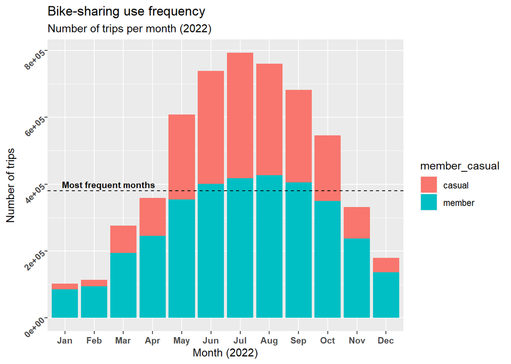

```r
#prepare data
number_rides_vs_month_membership <-tripdata_2022_cleaned2 %>%
  group_by(month,member_casual) %>%
  summarize(number_of_rides = n())

#column graph vis
bikesharing_monthly_frequency <- ggplot(data = number_rides_vs_month_membership,
       mapping = aes(x = month, y = number_of_rides,
                     fill = member_casual)) +
  geom_col() +
  geom_hline(yintercept=3.8e5,linetype=2) +
  labs(title = "Bike-sharing use frequency", subtitle = "Number of trips per month (2022)",
       x = "Month (2022)", y = "Number of trips") +
  theme(axis.text.x = element_text(face ="bold"), axis.text.y = element_text(face ="bold", angle = 45)) +
  annotate("text", x = 2.5, y = 4e5, label = "Most frequent months", fontface = "bold", size = 3)

bikesharing_monthly_frequency
```

In the graph, the use frequency of the bike-sharing service by month is shown. We can deduce from it that the bike-sharing service is most used from May to October, frequency drops down in November, March and April, and it’s barely used from December to January. It is also observed that the frequency of use between casual users is much more variable than between members, which can lead to the conclusion that members have planned to use the service more frequently.

#### 2) Daily behavior:

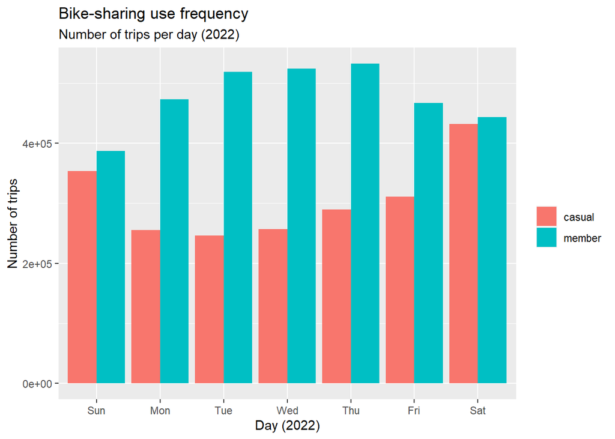

```r
#prepare data
number_rides_vs_weekday_membership <- tripdata_2022_cleaned2 %>%
  group_by(weekday, member_casual) %>%
  summarize(number_of_rides = n())

#column graph viz
bikesharing_monthly_frequency <- ggplot(data = number_rides_vs_weekday_membership, aes(x = weekday, y = number_of_rides, fill = member_casual)) +
  geom_col(position='dodge') +
  labs(title = "Bike-sharing use frequency", subtitle = "Number of trips per day (2022)",
       x = "Day (2022)", y = "Number of trips") +
  theme(legend.title = element_blank())

bikesharing_monthly_frequency
```

This graph shows the number of trips done by day for casual users and members. It is observed that members’ use of the service is quite homogeneous, while casual users take a ride more often in the weekends. This trend would be more exaggerated if we show data only from May to October.

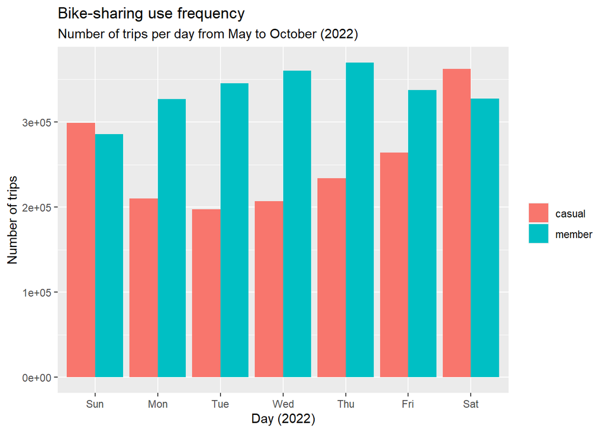

```r
#prepare data
number_rides_vs_weekday_membership_summer <- tripdata_2022_cleaned2 %>%
  filter(month == "May" | month == "Jun" | month == "Jul" | month == "Aug" | month == "Sep" | month == "Oct" ) %>%
  group_by(weekday, member_casual) %>%
  summarize(number_of_rides = n())

#column graph viz
bikesharing_monthly_frequency_summer <- ggplot(data = number_rides_vs_weekday_membership_summer, aes(x = weekday, y = number_of_rides, fill = member_casual)) +
  geom_col(position='dodge') +
  labs(title = "Bike-sharing use frequency", subtitle = "Number of trips per day from May to October (2022)",
       x = "Day (2022)", y = "Number of trips") +
  theme(legend.title = element_blank())

bikesharing_monthly_frequency_summer
```

#### 3) Trip duration:

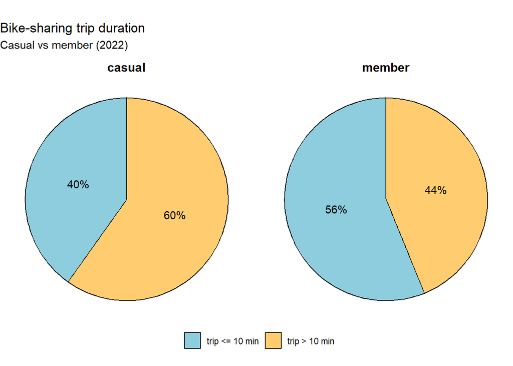

```r
#prepare data
trip_duration_membership <- tripdata_2022_cleaned2 %>%
  select(member_casual, trip_length) %>%
  mutate(trip_length_num = as.numeric(trip_length)) %>%
  mutate(trip_10 = case_when(trip_length_num > 600 ~ "trip > 10 min", TRUE ~ "trip <= 10 min")) %>%
  group_by(member_casual, trip_10) %>%
  summarize(total_count = n())

#pie_chart_data1 <- results1_duration_membership2b %>%
  #group_by(member_casual, trip_10) %>%
  #summarize(total_count = n())
pie_chart_data_final <- trip_duration_membership %>%
  group_by(member_casual) %>%
  mutate(percentage = total_count/(sum(total_count))) %>%
  mutate(labels = scales::percent(percentage))

#pie chart viz
ggplot(data = pie_chart_data_final, aes(x = "", y = percentage, fill = trip_10)) +
  geom_col(color = "black") +
  geom_text(aes(label = labels), position = position_stack(vjust = 0.5)) +
  coord_polar(theta = "y") +
  theme_void() +
  facet_wrap(~member_casual) +
  labs(title = "Bike-sharing trip duration", subtitle = "Casual vs member (2022)") +
  scale_fill_manual(values = c("#8ECDDD","#FFCC70")) +
  theme(legend.title = element_blank(), legend.position = "bottom", strip.text.x = element_text(size = 12, face = "bold", margin = margin(10,0,0,0)))
```

## Suggestions and future plans:

We can summarize the results from the analysis:

1. In general, the use of the service increases a lot from May to October (hot months), specially for casual costumers.
2. Casual members use the bike-sharing service more often on weekends, while members use it everyday.
3. Casual members usually take longer trips than members.

In this case study, our objective is trying to convert some casual customers into members. With this purpose, I’d suggest adding more membership plans that allow different kinds of customers to meet their needs. In order to gain some customers that occasionally use the service from November to March (cold months), I’d create a winter membership for a reasonable price. Moreover, since the casual customers use the service more often on the weekends I’d also create a new annual membership plan only for the weekends.

On the other hand, I’d modify the pricing structure. First, I’d create a different pricing for single-trips and day-trips depending on the month of the year, making the trips in “cold months” cheaper and more expensive during “hot months”. I don’t know if a trip limit exists at the moment, but I’d add extra charges for trips longer than 15 or 20 mins for casual customers, and a higher cap (like 40 mins) and a lower fee for members.